# 440 Reproducibility and Statistics Assignment Homework

This is the politics data file loaded.

```r
pols<-read.csv("politics.csv")
```

```r
str(pols)
```

```
## 'data.frame':    132 obs. of  7 variables:
##  $ subject      : int  1 2 3 4 5 6 7 8 9 10 ...
##  $ party        : Factor w/ 3 levels "democrat","independent",..: 3 3 2 2 2 3 3 2 3 2 ...
##  $ testtime     : Factor w/ 2 levels "post","pre": 2 2 2 2 2 2 2 2 2 2 ...
##  $ optimismscore: int  52 51 69 51 61 31 57 48 42 64 ...
##  $ minwage      : Factor w/ 2 levels "no","yes": 1 1 2 1 2 1 1 1 1 1 ...
##  $ sex          : Factor w/ 2 levels "female","male": 2 2 1 2 2 2 2 2 2 2 ...
##  $ income       : num  37.3 42.3 73 33.8 57.3 ...
```

```r
head(pols$subject[pols$testtime=="pre"]==pols$subject[pols$testtime=="post"])
```

```
## [1] TRUE TRUE TRUE TRUE TRUE TRUE
```

```r
trues<-pols$testtime=="pre"
sum(!(pols$subject[trues]==pols$subject[!trues]))
```

```
## [1] 0
```

```r
sum(!(pols$party[trues]==pols$party[!trues]))
```

```
## [1] 0
```

```r
sum(!(pols$subject[trues]==pols$subject[!trues]))
```

```
## [1] 0
```

```r
sum(!(pols$sex[trues]==pols$sex[!trues]))
```

```
## [1] 0
```

```r
sum(!(pols$income[trues]==pols$income[!trues]))
```

```
## [1] 0
```

```r
pols$subject<-factor(pols$subject)
pols$testtime<-factor(pols$testtime, levels=c("pre", "post"))
```

By summarizing the post-test optimism scores, below you can find the minimum is 18, the mean is 59.82, and the variance for the post-test optimism scores is 336.27.

```r
summary(pols$optimismscore[pols$testtime=="post"])
```

```
##    Min. 1st Qu.  Median    Mean 3rd Qu.    Max.
##   18.00   45.00   61.00   59.82   73.00   94.00
```

```r
var(pols$optimismscore[pols$testtime=="post"])
```

```
## [1] 336.2741
```

Here is a histogram of post-test optimism scores.

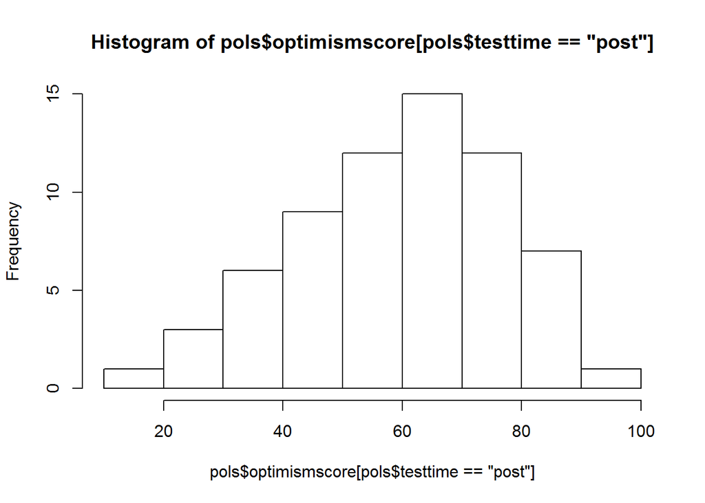

```r
hist(pols$optimismscore[pols$testtime=="post"])
```

In order to compare the independent political affiliation to a person’s sex, I completed a table and chi-squared test. The results show x-square=0.72674, df=2, p-value=0.6953, thus, a null hypothesis.

```r
tab<-table(pols$party[pols$testtime=="pre"],pols$sex[pols$testtime=="pre"])
tab
```

```
##
##               female male
##   democrat        14   12
##   independent      7   10
##   republican      12   11
```

```r
chisq.test(pols$party[pols$testtime=="pre"],pols$sex[pols$testtime=="pre"])
```

```
##
##  Pearson's Chi-squared test
##
## data:  pols$party[pols$testtime == "pre"] and pols$sex[pols$testtime == "pre"]
## X-squared = 0.72674, df = 2, p-value = 0.6953
```

```r
t.test(pols$income[pols$sex=="male" & pols$testtime=="pre"],pols$income[pols$sex=="female" & pols$testtime=="pre"])
```

```
##
##  Welch Two Sample t-test
##
## data:  pols$income[pols$sex == "male" & pols$testtime == "pre"] and pols$income[pols$sex == "female" & pols$testtime == "pre"]
## t = -1.5714, df = 61.623, p-value = 0.1212
## alternative hypothesis: true difference in means is not equal to 0
## 95 percent confidence interval:
##  -19.23627   2.30508
## sample estimates:
## mean of x mean of y
##  38.80751  47.27310
```

```r
library("dplyr")
```

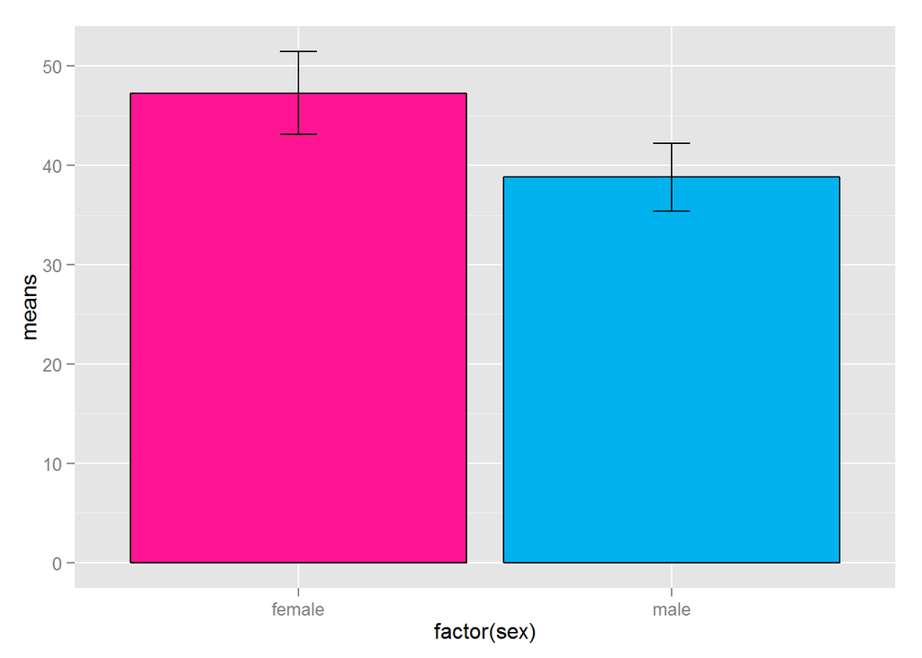

```r
temp<-pols[pols$testtime=="pre",]%>%group_by(sex)%>%summarize(means=mean(income),
              sems=sd(income)/sqrt(length(income)))
library("ggplot2")
f<-ggplot(temp,aes(x=factor(sex),y=means))+
    geom_bar(stat="identity", color="black",fill=c("deeppink","deepskyblue2"))+
    geom_errorbar(aes(ymax=means+sems, ymin=means-sems), width=.1)
f
```

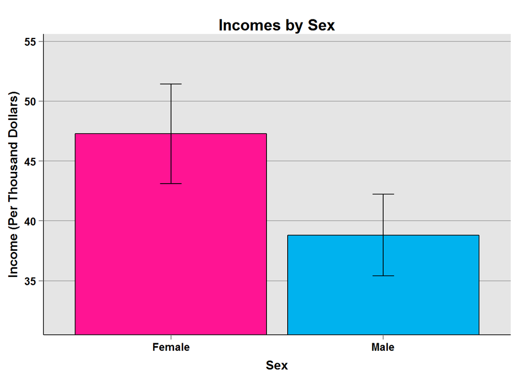

```r
f<-f+ggtitle("Incomes by Sex")+
    labs(x="Sex", y="Income (Per Thousand Dollars)")+
    scale_x_discrete(breaks=c("female","male"),labels=c("Female","Male"))+
    theme(plot.title=element_text(size=15,face="bold",vjust=.5))+
    theme(axis.title.x=element_text(size=12,face="bold",vjust=-.25))+
    theme(axis.title.y=element_text(size=12,face="bold",vjust=1))+
    theme(axis.text.x=element_text(size=10,face="bold",color="black"))+
    theme(axis.text.y=element_text(size=10,face="bold",color="black"))+
    coord_cartesian(ylim=c(min(temp$means)-2*max(temp$sems),max(temp$means)+2*max(temp$sems)))+
    theme(panel.border=element_blank(), axis.line=element_line())+
    theme(panel.grid.major.x=element_blank())+
    theme(panel.grid.major.y=element_line(color="darkgrey"))+
    theme(panel.grid.minor.y=element_blank())
f
```

[output not shown]

To see if party affiliation and sex predict posttest optimism score independently or in an interaction I used a 2-way between-subjects ANOVA and created a plot graph.

```r
 summary(aov(optimismscore~party*sex,data=pols[pols$testtime=="post",]))
```

```
##             Df Sum Sq Mean Sq F value  Pr(>F)
## party        2  10147    5074  27.063 4.2e-09 ***
## sex          1      7       7   0.040   0.843
## party:sex    2    455     227   1.213   0.304
## Residuals   60  11248     187
## ---
## Signif. codes:  0 '***' 0.001 '**' 0.01 '*' 0.05 '.' 0.1 ' ' 1
```

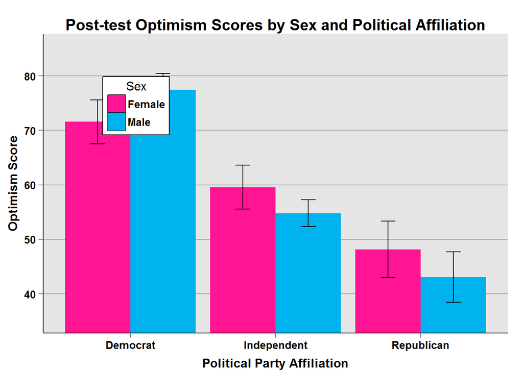

```r
temp<-pols[pols$testtime=="post",]%>%group_by(party,sex)%>%
    summarize(means=mean(optimismscore),sems=sd(optimismscore)/sqrt(length(optimismscore)))
library("gplots")
col1=col2hex("deeppink")
col2=col2hex("deepskyblue2")
f<-ggplot(temp, aes(x=party, y=means, fill=sex))+
    geom_bar(stat="identity",position=position_dodge())+
    scale_fill_manual(values=c(col1,col2),name="Sex",breaks=c("female","male"),labels=c("Female", "Male"))+
    theme(legend.key=element_rect(color="black"))+
    geom_errorbar(aes(ymax=means+sems, ymin=means-sems),width=.2,position=position_dodge(.9))+
    ggtitle("Post-test Optimism Scores by Sex and Political Affiliation")+
    labs(x="Political Party Affiliation",y="Optimism Score")+
    scale_x_discrete(breaks=c("democrat","independent","republican"),labels=c("Democrat","Independent","Republican"))+
    theme(plot.title=element_text(size=15,face="bold",vjust=.5))+
    theme(axis.title.x=element_text(size=12,face="bold",vjust=-.25))+
    theme(axis.title.y=element_text(size=12,face="bold",vjust=1))+
    theme(axis.text.x=element_text(size=10,face="bold",color="black"))+
    theme(axis.text.y=element_text(size=10,face="bold",color="black"))+
    coord_cartesian(ylim=c(min(temp$means)-2*max(temp$sems),max(temp$means)+2*max(temp$sems)))+
    theme(panel.border=element_blank(),axis.line=element_line())+
    theme(panel.grid.major.x=element_blank())+
    theme(panel.grid.major.y=element_line(color="darkgrey"))+
    theme(panel.grid.minor.y=element_blank())+
    theme(legend.position=c(.2,.76))+
    theme(legend.background=element_blank())+
    theme(legend.background=element_rect(color="black"))+
    theme(legend.title=element_blank())+
    theme(legend.title=element_text(size=12))+
    theme(legend.title.align=.5)+
    theme(legend.text=element_text(size=10,face="bold"))
f
```

Here is a line graph showing the same data, along with error bars.

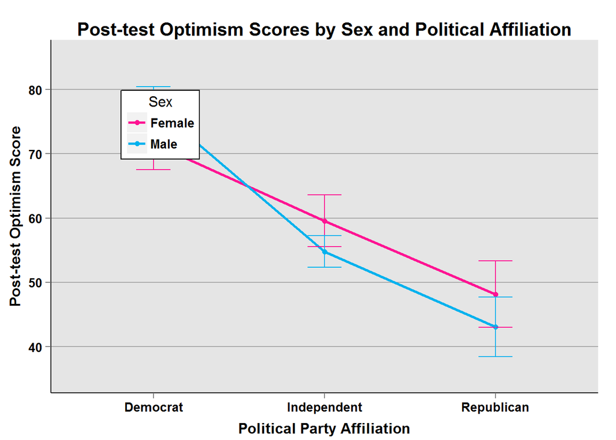

```r
f<-ggplot(temp, aes(x=party, y=means, group=sex, color=sex))+
    geom_line(size=1)+
    geom_point(size=2)+
    scale_color_manual(values=c(col1,col2),name="Sex",breaks=c("female","male"),labels=c("Female", "Male"))+
    geom_errorbar(aes(ymax=means+sems, ymin=means-sems),width=.2)+
    ggtitle("Post-test Optimism Scores by Sex and Political Affiliation")+
    labs(x="Political Party Affiliation",y="Post-test Optimism Score")+
    scale_x_discrete(breaks=c("democrat","independent","republican"),labels=c("Democrat","Independent","Republican"))+
    theme(plot.title=element_text(size=15,face="bold",vjust=.5))+
    theme(axis.title.x=element_text(size=12,face="bold",vjust=-.25))+
    theme(axis.title.y=element_text(size=12,face="bold",vjust=1))+
    theme(axis.text.x=element_text(size=10,face="bold",color="black"))+
    theme(axis.text.y=element_text(size=10,face="bold",color="black"))+
    coord_cartesian(ylim=c(min(temp$means)-2*max(temp$sems),max(temp$means)+2*max(temp$sems)))+
    theme(panel.border=element_blank(),axis.line=element_line())+
    theme(panel.grid.major.x=element_blank())+
    theme(panel.grid.major.y=element_line(color="darkgrey"))+
    theme(panel.grid.minor.y=element_blank())+
    theme(legend.position=c(.2,.76))+
    theme(legend.background=element_blank())+
    theme(legend.background=element_rect(color="black"))+
    theme(legend.title=element_blank())+
    theme(legend.title=element_text(size=12))+
    theme(legend.title.align=.5)+
    theme(legend.text=element_text(size=10,face="bold"))
f
```

```r
summary(aov(optimismscore~testtime*party+Error(sex/testtime),data=pols))
```

```
##
## Error: sex
##       Df Sum Sq Mean Sq
## party  1  80.37   80.37
##
## Error: sex:testtime
##                Df Sum Sq Mean Sq
## testtime        1  770.9   770.9
## testtime:party  1    0.9     0.9
##
## Error: Within
##                 Df Sum Sq Mean Sq F value Pr(>F)
## party            2  21896   10948   60.74 <2e-16 ***
## testtime:party   2     54      27    0.15  0.861
## Residuals      124  22350     180
## ---
## Signif. codes:  0 '***' 0.001 '**' 0.01 '*' 0.05 '.' 0.1 ' ' 1
```

```r
summary(lm(optimismscore[testtime=="post"]~optimismscore[testtime=="pre"]+party[testtime=="pre"], data=pols))
```

```
##
## Call:
## lm(formula = optimismscore[testtime == "post"] ~ optimismscore[testtime ==
##     "pre"] + party[testtime == "pre"], data = pols)
##
## Residuals:
##     Min      1Q  Median      3Q     Max
## -22.866  -2.562   1.267   3.901   8.948
##
## Coefficients:
##                                     Estimate Std. Error t value Pr(>|t|)
## (Intercept)                           8.1219     4.2616   1.906   0.0613
## optimismscore[testtime == "pre"]      0.9419     0.0583  16.154   <2e-16
## party[testtime == "pre"]independent  -1.3310     2.1284  -0.625   0.5340
## party[testtime == "pre"]republican    0.7210     2.5000   0.288   0.7740
##
## (Intercept)                         .
## optimismscore[testtime == "pre"]    ***
## party[testtime == "pre"]independent
## party[testtime == "pre"]republican
## ---
## Signif. codes:  0 '***' 0.001 '**' 0.01 '*' 0.05 '.' 0.1 ' ' 1
##
## Residual standard error: 6.022 on 62 degrees of freedom
## Multiple R-squared:  0.8971, Adjusted R-squared:  0.8922
## F-statistic: 180.3 on 3 and 62 DF,  p-value: < 2.2e-16
```

After performing a Multiple Regression Analysis, you can see from the above information that R2=0, 90, F(3, 62)=180.3, p<.001, demonstrates a tight slope of 0.94, suggesting good probability of predictibity between pre- and post-test optimism scores.